EMPLOYEE RETENTION PREDICITVE ANALYSIS

DEFINE PROBLEM

Background: Frequent voluntary turnover has a negative impact on employee morale, productivity, and company revenue. Recruiting and training a new employee requires staff time and money. According to the Bureau of Labor Statistics, turnover is highest in industries such as trade and utilities, construction, retail, customer service, hospitality, and service.

Objective: The purpose of this project is to build several models that predict employee retention/turnover of employees. The sample data is from employees’ previous exit interviews. The data set contains variables such as employee satisfaction, number of projects, salary level,last evaluation, average monthly hours, position, time at the company, promotion during last five years, and work accidents.

DATA COLLECTION

Code: I loaded the necessary packages.

```r
library(ggplot2)
```

[output not shown]

```r
library(corrplot)
library(tidyverse)
library(dummies)
library(caret)
library(visreg)
library(data.table)
library(plyr)
library(stats)
library(dplyr)
library(glmnet)
library(hexbin)
library(xgboost)
library(skimr)
library(kableExtra)
library(jtools)
```

Read in the sample data from a .csv file.

```r
hrdata <- read.csv("HR_comma_sep.csv", sep=",",header = TRUE)
```

EXPLORATORY DATA ANALYSIS

I began EDA by doing some basic analysis (str, missing values, head, and summary). There 14,999 records and 10 variables. Two variables are factors.

```r
str(hrdata)
```

```
'data.frame':   14999 obs. of  10 variables:
 $ satisfaction_level   : num  0.38 0.8 0.11 0.72 0.37 0.41 0.1 0.92 0.89 0.42 ...
 $ last_evaluation      : num  0.53 0.86 0.88 0.87 0.52 0.5 0.77 0.85 1 0.53 ...
 $ number_project       : int  2 5 7 5 2 2 6 5 5 2 ...
 $ average_montly_hours : int  157 262 272 223 159 153 247 259 224 142 ...
 $ time_spend_company   : int  3 6 4 5 3 3 4 5 5 3 ...
 $ Work_accident        : int  0 0 0 0 0 0 0 0 0 0 ...
 $ left                 : int  1 1 1 1 1 1 1 1 1 1 ...
 $ promotion_last_5years: int  0 0 0 0 0 0 0 0 0 0 ...
 $ Department           : Factor w/ 10 levels "accounting","hr",..: 8 8 8 8 8 8 8 8 8 8 ...
 $ salary               : Factor w/ 3 levels "high","low","medium": 2 3 3 2 2 2 2 2 2 2 ...
```

I checked to see if there were any missing values. No missing values were detected.

```r
map(hrdata,~sum(is.na(.)))
```

```
$satisfaction_level
[1] 0

$last_evaluation
[1] 0

$number_project
[1] 0

$average_montly_hours
[1] 0

$time_spend_company
[1] 0

$Work_accident
[1] 0

$left
[1] 0

$promotion_last_5years
[1] 0

$Department
[1] 0

$salary
[1] 0
```

Continued my exploratory data analysis by applying the head and summary functions to the data.

```r
head(hrdata)
```

|  | satisfaction_level | last_evaluation | number_project | average_montly_hours | time_spend_company | Work_accident | left | promotion_last_5years | Department | salary |
| --- | --- | --- | --- | --- | --- | --- | --- | --- | --- | --- |
| 1 | 0.38 | 0.53 | 2 | 157 | 3 | 0 | 1 | 0 | sales | low |
| 2 | 0.80 | 0.86 | 5 | 262 | 6 | 0 | 1 | 0 | sales | medium |
| 3 | 0.11 | 0.88 | 7 | 272 | 4 | 0 | 1 | 0 | sales | medium |
| 4 | 0.72 | 0.87 | 5 | 223 | 5 | 0 | 1 | 0 | sales | low |
| 5 | 0.37 | 0.52 | 2 | 159 | 3 | 0 | 1 | 0 | sales | low |
| 6 | 0.41 | 0.50 | 2 | 153 | 3 | 0 | 1 | 0 | sales | low |

```r
summary(hrdata)
```

```
 satisfaction_level last_evaluation  number_project  average_montly_hours
 Min.   :0.0900     Min.   :0.3600   Min.   :2.000   Min.   : 96.0
 1st Qu.:0.4400     1st Qu.:0.5600   1st Qu.:3.000   1st Qu.:156.0
 Median :0.6400     Median :0.7200   Median :4.000   Median :200.0
 Mean   :0.6128     Mean   :0.7161   Mean   :3.803   Mean   :201.1
 3rd Qu.:0.8200     3rd Qu.:0.8700   3rd Qu.:5.000   3rd Qu.:245.0
 Max.   :1.0000     Max.   :1.0000   Max.   :7.000   Max.   :310.0

 time_spend_company Work_accident         left        promotion_last_5years
 Min.   : 2.000     Min.   :0.0000   Min.   :0.0000   Min.   :0.00000
 1st Qu.: 3.000     1st Qu.:0.0000   1st Qu.:0.0000   1st Qu.:0.00000
 Median : 3.000     Median :0.0000   Median :0.0000   Median :0.00000
 Mean   : 3.498     Mean   :0.1446   Mean   :0.2381   Mean   :0.02127
 3rd Qu.: 4.000     3rd Qu.:0.0000   3rd Qu.:0.0000   3rd Qu.:0.00000
 Max.   :10.000     Max.   :1.0000   Max.   :1.0000   Max.   :1.00000

       Department      salary
 sales      :4140   high  :1237
 technical  :2720   low   :7316
 support    :2229   medium:6446
 IT         :1227
 product_mng: 902
 marketing  : 858
 (Other)    :2923
```

Created a correlation matrix and plot. The proposed response variable time_with_company has the strongest correlation with -(statisfaction_level), last_evaluation, number_project, average_montly_hours, and left. number_project has the strongest correlation.

```r
corMatrix <- cor(hrdata[1:8], use="complete.obs",method = "pearson")
round(corMatrix,2)
```

```
                      satisfaction_level last_evaluation number_project
satisfaction_level                  1.00            0.11          -0.14
last_evaluation                     0.11            1.00           0.35
number_project                     -0.14            0.35           1.00
average_montly_hours               -0.02            0.34           0.42
time_spend_company                 -0.10            0.13           0.20
Work_accident                       0.06           -0.01           0.00
left                               -0.39            0.01           0.02
promotion_last_5years               0.03           -0.01          -0.01
                      average_montly_hours time_spend_company Work_accident  left
satisfaction_level                   -0.02              -0.10          0.06 -0.39
last_evaluation                       0.34               0.13         -0.01  0.01
number_project                        0.42               0.20          0.00  0.02
average_montly_hours                  1.00               0.13         -0.01  0.07
time_spend_company                    0.13               1.00          0.00  0.14
Work_accident                        -0.01               0.00          1.00 -0.15
left                                  0.07               0.14         -0.15  1.00
promotion_last_5years                 0.00               0.07          0.04 -0.06
                      promotion_last_5years
satisfaction_level                     0.03
last_evaluation                       -0.01
number_project                        -0.01
average_montly_hours                   0.00
time_spend_company                     0.07
Work_accident                          0.04
left                                  -0.06
promotion_last_5years                  1.00
```

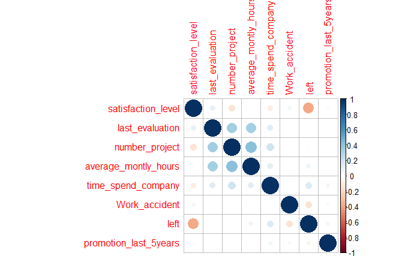

```r
corrplot(corMatrix, method = "circle")
```

The histogram below shows that the majority of the employees (~67%) leave before the third year. This group may be of interest later.

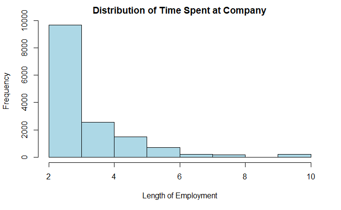

```r
hist(hrdata$time_spend_company, main="Distribution of Time Spent at Company", xlab="Length of Employment", breaks=7, col="lightblue")
```

I changed several variables to factors to make the plots reader friendly.

```r
hrdata$leftFactor <- factor(hrdata$left,levels=c(0,1),
                     labels=c("Did Not Leave Company","Left Company"))
hrdata$promoFactor <- factor(hrdata$promotion_last_5years,levels=c(0,1),
                     labels=c("Did Not Get Promoted","Did Get Promoted"))
hrdata$wrkAcdntFactor <- factor(hrdata$Work_accident,levels=c(0,1),
                      labels=c("No Accident","Accident"))
```

I created a number of scatterplots to view the relationship between the response and several varables of interest.